# Labcyte-RT Data Analysis (MOIRAI BED FILES)

# 1 Data load and QC in R

```r
library(CAGEr)
library(data.table)
library(dplyr)
```

```r
library(ggplot2)
library(gplots)
library('RColorBrewer')
library(magrittr)
library(plyr)
library(MultiAssayExperiment)
library(SummarizedExperiment)
library(tibble)
library(reshape)
library(vegan)
data("nanoCAGE2017barcodes", package = "smallCAGEqc")
```

MOIRAI shortcuts

```r
WORKFLOW       <- "OP-WORKFLOW-CAGEscan-short-reads-v2.1~rc1"
MOIRAI_PROJ    <- "project/Labcyte"
MOIRAI_USER    <- "nanoCAGE2"
ASSEMBLY       <- "mm9"
BASEDIR        <- "/osc-fs_home/scratch/moirai"
MOIRAI_BASE    <- file.path(BASEDIR, MOIRAI_USER)
MOIRAI_RESULTS <- file.path(MOIRAI_BASE, MOIRAI_PROJ)
```

# 2 Load CAGE libraries

## 2.1 Load summary statistics from MOIRAI and polish the names

```r
libs <- smallCAGEqc::loadMoiraiStats(
  pipeline  = "OP-WORKFLOW-CAGEscan-short-reads-v2.0",
  multiplex = file.path( MOIRAI_BASE, "input/171227_M00528_0321_000000000-B4GLP.multiplex.txt"),
  summary   = file.path( MOIRAI_RESULTS,"171227_M00528_0321_000000000-B4GLP.OP-WORKFLOW-CAGEscan-short-reads-v2.1~rc1.20180104125850/text/summary.txt"))
libs$barcode_ID <- libs$barcode
levels(libs$barcode_ID) %<>% match(nanoCAGE2017barcodes$barcodes)
libs$inputFiles <- list.files(path = "/osc-fs_home/scratch/moirai/nanoCAGE2/project/Labcyte/171227_M00528_0321_000000000-B4GLP.OP-WORKFLOW-CAGEscan-short-reads-v2.1~rc1.20180104125850/CAGEscan_fragments")
libs$inputFiles <- paste0("/osc-fs_home/scratch/moirai/nanoCAGE2/project/Labcyte/171227_M00528_0321_000000000-B4GLP.OP-WORKFLOW-CAGEscan-short-reads-v2.1~rc1.20180104125850/CAGEscan_fragments/", libs$inputFiles)
libs$inputFilesType <- c("bed")
libs$sampleLabels <- as.character(libs$samplename)
libs
```

```
##        samplename  group barcode    index total extracted cleaned tagdust
## ACACAG     ACACAG ACACAG  ACACAG TAGGCATG     0     42054   32450    4446
## ACACGT     ACACGT ACACGT  ACACGT TAGGCATG     0     39556   30362    3435
## ACACTC     ACACTC ACACTC  ACACTC TAGGCATG     0    159844  121202   16681
## ACAGAT     ACAGAT ACAGAT  ACAGAT TAGGCATG     0    138710  109459   14604
## ACAGCA     ACAGCA ACAGCA  ACAGCA TAGGCATG     0    158662  118015   17660
## ACAGTG     ACAGTG ACAGTG  ACAGTG TAGGCATG     0    218169  162650   24469
## ACATAC     ACATAC ACATAC  ACATAC TAGGCATG     0    252993  170605   43474
## ACATCT     ACATCT ACATCT  ACATCT TAGGCATG     0     33745   27224    3571
## ACATGA     ACATGA ACATGA  ACATGA TAGGCATG     0     32474   25537    3094
## AGTACG     AGTACG AGTACG  AGTACG TAGGCATG     0     14180   10760    1275
## AGTAGC     AGTAGC AGTAGC  AGTAGC TAGGCATG     0     56598   43154    4590
## AGTATA     AGTATA AGTATA  AGTATA TAGGCATG     0     15195   10726    1692
## AGTCAG     AGTCAG AGTCAG  AGTCAG TAGGCATG     0     18231   12169    2451
## AGTCGT     AGTCGT AGTCGT  AGTCGT TAGGCATG     0     42894   27736    5143
## AGTCTC     AGTCTC AGTCTC  AGTCTC TAGGCATG     0      3059    2204     193
## AGTGAT     AGTGAT AGTGAT  AGTGAT TAGGCATG     0    168934  137231   12654
## AGTGCA     AGTGCA AGTGCA  AGTGCA TAGGCATG     0    428768  340280   36348
## AGTGTG     AGTGTG AGTGTG  AGTGTG TAGGCATG     0     16988   11880    1582
## ATCACG     ATCACG ATCACG  ATCACG TAGGCATG     0     11697    7038    1808
## ATCAGC     ATCAGC ATCAGC  ATCAGC TAGGCATG     0   1053249  719844   99891
## ATCATA     ATCATA ATCATA  ATCATA TAGGCATG     0     17945   10155    3332
## ATCGAT     ATCGAT ATCGAT  ATCGAT TAGGCATG     0     10403    7116     762
## ATCGCA     ATCGCA ATCGCA  ATCGCA TAGGCATG     0     43925   30747    4033
## ATCGTG     ATCGTG ATCGTG  ATCGTG TAGGCATG     0      5852    3888     545
## ATCTAC     ATCTAC ATCTAC  ATCTAC TAGGCATG     0     61931   39776    7975
## ATCTCT     ATCTCT ATCTCT  ATCTCT TAGGCATG     0      7558    4713     951
## ATCTGA     ATCTGA ATCTGA  ATCTGA TAGGCATG     0    198657  131168   17902
## CACACG     CACACG CACACG  CACACG TAGGCATG     0   1333918  777491  188522
## CACAGC     CACAGC CACAGC  CACAGC TAGGCATG     0      8329    6011     604
## CACATA     CACATA CACATA  CACATA TAGGCATG     0     49911   31480    6737
## CACGAT     CACGAT CACGAT  CACGAT TAGGCATG     0     14078    8046    1768
## CACGCA     CACGCA CACGCA  CACGCA TAGGCATG     0    168925  101801   20625
## CACGTG     CACGTG CACGTG  CACGTG TAGGCATG     0     30261   17471    3498
## CACTAC     CACTAC CACTAC  CACTAC TAGGCATG     0    551765  297147   87676
## CACTCT     CACTCT CACTCT  CACTCT TAGGCATG     0    399697  210815   58589
## CACTGA     CACTGA CACTGA  CACTGA TAGGCATG     0      6506    3906     712
## CGACAG     CGACAG CGACAG  CGACAG TAGGCATG     0      5787    3355     763
## CGACGT     CGACGT CGACGT  CGACGT TAGGCATG     0     50902   28765    5996
## CGACTC     CGACTC CGACTC  CGACTC TAGGCATG     0    151581   86422   16624
```

[output cut: 229 more lines]

```
## GAGAGC            bed       GAGAGC
## GAGATA            bed       GAGATA
## GAGCAG            bed       GAGCAG
## GAGCGT            bed       GAGCGT
## GAGCTC            bed       GAGCTC
## GAGTAC            bed       GAGTAC
## GAGTCT            bed       GAGTCT
## GAGTGA            bed       GAGTGA
## GCTACG            bed       GCTACG
## GCTAGC            bed       GCTAGC
## GCTATA            bed       GCTATA
## GCTCAG            bed       GCTCAG
## GCTCGT            bed       GCTCGT
## GCTCTC            bed       GCTCTC
## GCTGAT            bed       GCTGAT
```

```r
plate <- read.table("plate.txt", sep = "\t", header = TRUE)
plate_10ng <- subset(plate, plate$RNA == 10)
plate_10ng_no_RNA <- plate[224:230,]
plate_10ng_all <- rbind(plate_10ng, plate_10ng_no_RNA)
rm(plate) ; rm(plate_10ng) ; rm(plate_10ng_no_RNA)
plate_10ng_all
```

```
##     well row col MASTER_MIX_vol     TSO TSO_vol BARCODE_ID BARCODE_SEQ
## 8    A08   A   8            350 80.0000     100          1      ACACAG
## 9    A09   A   9            350 80.0000     100          2      ACACGT
## 10   A10   A  10            350 80.0000     100          3      ACACTC
## 11   A11   A  11            350 80.0000     100          4      ACAGAT
## 12   A12   A  12            350 80.0000     100          5      ACAGCA
## 13   A13   A  13            350 80.0000     100          6      ACAGTG
## 14   A14   A  14            350 80.0000     100          7      ACATAC
## 32   B08   B   8            350 40.0000      50          8      ACATCT
## 33   B09   B   9            350 40.0000      50          9      ACATGA
## 34   B10   B  10            350 40.0000      50         10      AGTACG
## 35   B11   B  11            350 40.0000      50         11      AGTAGC
## 36   B12   B  12            350 40.0000      50         12      AGTATA
## 37   B13   B  13            350 40.0000      50         13      AGTCAG
## 38   B14   B  14            350 40.0000      50         14      AGTCGT
```

[output cut: 198 more lines]

```r
libs <- cbind(libs, plate_10ng_all[match(libs$barcode, plate_10ng_all$BARCODE_SEQ),])
libs$PRIMERS_RATIO <- sub("no_RT_PRIMERS", "NA", libs$PRIMERS_RATIO)
libs$PRIMERS_RATIO <- as.numeric(libs$PRIMERS_RATIO)
libs$RNA <- as.numeric(libs$RNA)
libs$PRIMERS_RATIO[is.na(libs$PRIMERS_RATIO)] <- "no_RT_PRIMERS"
libs$plateID <- "A"
```

## 2.2 Control on barcode extraction

```r
found_bc <- system("zcat /sequencedata/MiSeq/171227_M00528_0321_000000000-B4GLP/Data/Intensities/BaseCalls/1_S1_L001_R1_001.fastq.gz | sed -n 2~4p | cut -c1-6 | sort | uniq -c", intern = TRUE)
found_bc <- read.table(text=found_bc)
colnames(found_bc) <- c("n", "bc")
found_bc %<>% as.tibble %>% arrange(dplyr::desc(n))
```

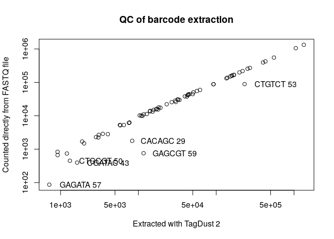

```r
libs$bc_extract_qc <- found_bc$n[match(libs$barcode, found_bc$bc)]

plot( libs$extracted
    , libs$bc_extract_qc
    , log = "xy"
    , xlab = "Extracted with TagDust 2"
    , ylab = "Counted directly from FASTQ file"
    , main = "QC of barcode extraction")
with(libs[libs$extracted / libs$bc_extract_qc > 2,], text(extracted * 2.5, bc_extract_qc, paste(barcode, barcode_ID)))
```

```r
libs[libs$extracted / libs$bc_extract_qc > 2,]
```

```
##        samplename  group barcode    index total extracted cleaned tagdust
## CACAGC     CACAGC CACAGC  CACAGC TAGGCATG     0      8329    6011     604
## CGATAC     CGATAC CGATAC  CGATAC TAGGCATG     0      1633    1032     117
## CTGCGT     CTGCGT CTGCGT  CTGCGT TAGGCATG     0      1318     973      67
## CTGTCT     CTGTCT CTGTCT  CTGTCT TAGGCATG     0    231518   60117  145048
## GAGATA     GAGATA GAGATA  GAGATA TAGGCATG     0       717     435      54
## GAGCGT     GAGCGT GAGCGT  GAGCGT TAGGCATG     0     11654    1146     245
##         rdna spikes mapped properpairs counts barcode_ID
## CACAGC  1710      4   4673        3616   1346         29
## CGATAC   483      1    581         339    166         43
## CTGCGT   278      0    640         396    170         50
## CTGTCT 26325     28  42593       30380   7757         53
## GAGATA   228      0    276         200    108         57
## GAGCGT 10262      1    787         519    202         59
##                                                                                                                                                                             inputFiles
## CACAGC /osc-fs_home/scratch/moirai/nanoCAGE2/project/Labcyte/171227_M00528_0321_000000000-B4GLP.OP-WORKFLOW-CAGEscan-short-reads-v2.1~rc1.20180104125850/CAGEscan_fragments/CACAGC.bed
## CGATAC /osc-fs_home/scratch/moirai/nanoCAGE2/project/Labcyte/171227_M00528_0321_000000000-B4GLP.OP-WORKFLOW-CAGEscan-short-reads-v2.1~rc1.20180104125850/CAGEscan_fragments/CGATAC.bed
## CTGCGT /osc-fs_home/scratch/moirai/nanoCAGE2/project/Labcyte/171227_M00528_0321_000000000-B4GLP.OP-WORKFLOW-CAGEscan-short-reads-v2.1~rc1.20180104125850/CAGEscan_fragments/CTGCGT.bed
## CTGTCT /osc-fs_home/scratch/moirai/nanoCAGE2/project/Labcyte/171227_M00528_0321_000000000-B4GLP.OP-WORKFLOW-CAGEscan-short-reads-v2.1~rc1.20180104125850/CAGEscan_fragments/CTGTCT.bed
## GAGATA /osc-fs_home/scratch/moirai/nanoCAGE2/project/Labcyte/171227_M00528_0321_000000000-B4GLP.OP-WORKFLOW-CAGEscan-short-reads-v2.1~rc1.20180104125850/CAGEscan_fragments/GAGATA.bed
## GAGCGT /osc-fs_home/scratch/moirai/nanoCAGE2/project/Labcyte/171227_M00528_0321_000000000-B4GLP.OP-WORKFLOW-CAGEscan-short-reads-v2.1~rc1.20180104125850/CAGEscan_fragments/GAGCGT.bed
##        inputFilesType sampleLabels well row col MASTER_MIX_vol    TSO
## CACAGC            bed       CACAGC  E08   E   8            350 5.0000
## CGATAC            bed       CGATAC  G08   G   8            350 1.2500
## CTGCGT            bed       CTGCGT  H08   H   8            350 0.6250
## CTGTCT            bed       CTGTCT  H11   H  11            350 0.6250
## GAGATA            bed       GAGATA  I08   I   8            350 0.3125
## GAGCGT            bed       GAGCGT  I10   I  10            350 0.3125
##        TSO_vol BARCODE_ID BARCODE_SEQ BARCODE_Source_Row
## CACAGC      50         29      CACAGC                  E
## CGATAC     100         43      CGATAC                  G
## CTGCGT      50         50      CTGCGT                  H
## CTGTCT      50         53      CTGTCT                  H
## GAGATA      25         57      GAGATA                  I
## GAGCGT      25         59      GAGCGT                  I
##        BARCODE_Source_Col RT_PRIMERS RT_PRIMERS_vol RNA RNA_vol RNA_group
## CACAGC                  1       0.00              0  10      25      10ng
## CGATAC                  1       0.00              0  10      25      10ng
## CTGCGT                  1       0.00              0  10      25      10ng
## CTGTCT                  4       0.50             25  10      25      10ng
## GAGATA                  1       0.00              0  10      25      10ng
## GAGCGT                  3       0.25             25  10      25      10ng
##        H2O_vol total_volume PRIMERS_RATIO plateID bc_extract_qc
## CACAGC      75          500 no_RT_PRIMERS       A          1783
## CGATAC      25          500 no_RT_PRIMERS       A           397
## CTGCGT      75          500 no_RT_PRIMERS       A           451
## CTGTCT      50          500          1.25       A         88635
## GAGATA     100          500 no_RT_PRIMERS       A            87
## GAGCGT      75          500          1.25       A           758
```

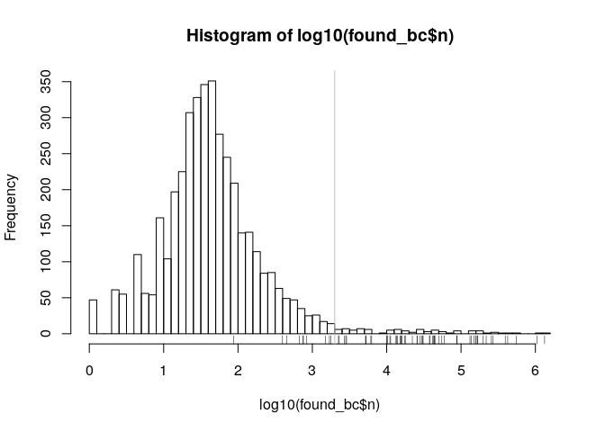

```r
found_bc$in_libs <- found_bc$bc %in% libs$barcode
found_bc$known   <- found_bc$bc %in% nanoCAGE2017barcodes$barcodes

hist(log10(found_bc$n), breaks = "fd")
rug(log10(libs$bc_extract_qc))
abline(v=log10(2e3), col = "grey")
```

True nanoCAGE barcodes that were not used in this experiment are very rare in the sequence files.

```r
found_bc %>% filter(known, !in_libs) %>% as.data.frame()
```

```
##      n     bc in_libs known
## 1  333 GCTGCA   FALSE  TRUE
## 2  118 GTAGCA   FALSE  TRUE
## 3   81 TATCAG   FALSE  TRUE
## 4   74 TCGACG   FALSE  TRUE
## 5   69 GTAGAT   FALSE  TRUE
## 6   67 TATAGC   FALSE  TRUE
## 7   67 TATGCA   FALSE  TRUE
## 8   44 GTAGTG   FALSE  TRUE
## 9   40 TCGAGC   FALSE  TRUE
## 10  30 TATGAT   FALSE  TRUE
## 11  30 TCGCAG   FALSE  TRUE
## 12  26 GTACGT   FALSE  TRUE
## 13  25 TATACG   FALSE  TRUE
## 14  24 GCTGTG   FALSE  TRUE
## 15  22 GTACAG   FALSE  TRUE
## 16  17 TCGATA   FALSE  TRUE
## 17  15 TATCTC   FALSE  TRUE
## 18  14 TATGTG   FALSE  TRUE
## 19  14 TCGCGT   FALSE  TRUE
## 20   8 TATCGT   FALSE  TRUE
## 21   7 GTATCT   FALSE  TRUE
## 22   5 TCGCTC   FALSE  TRUE
## 23   4 GTACTC   FALSE  TRUE
## 24   2 GTATAC   FALSE  TRUE
## 25   2 TATATA   FALSE  TRUE
```

Conversely, barcodes that are highly abundant but not used in the experiment are not true nanoCAGE barcodes. They may be related to higly abundant true barcodes.

```r
found_bc %>% filter(!in_libs, n > 2e3) %>% as.data.frame
```

```
##        n     bc in_libs known
## 1  94905 TGGGCA   FALSE FALSE
## 2  64818 CCTGTC   FALSE FALSE
## 3  33512 CACACA   FALSE FALSE
## 4  20717 CACCTG   FALSE FALSE
## 5  16126 ACTGTC   FALSE FALSE
## 6  10444 CGAGCG   FALSE FALSE
## 7   6097 ATCCTG   FALSE FALSE
## 8   4887 GGCGCG   FALSE FALSE
## 9   4886 CACATG   FALSE FALSE
## 10  4571 CACTCC   FALSE FALSE
## 11  4138 CACACC   FALSE FALSE
## 12  4122 GCTGTC   FALSE FALSE
## 13  4081 ACCTGT   FALSE FALSE
## 14  4040 CACACT   FALSE FALSE
## 15  3902 ACAGGG   FALSE FALSE
## 16  3891 CATACG   FALSE FALSE
## 17  3750 ACAGCT   FALSE FALSE
## 18  3531 TAGAGC   FALSE FALSE
## 19  3312 GCCTGT   FALSE FALSE
## 20  3112 ACACCT   FALSE FALSE
## 21  2980 ATCTGC   FALSE FALSE
## 22  2930 CACTGT   FALSE FALSE
## 23  2848 TACACG   FALSE FALSE
## 24  2437 AACTGC   FALSE FALSE
## 25  2399 CAAGCA   FALSE FALSE
## 26  2311 AGGGCA   FALSE FALSE
## 27  2085 AACACG   FALSE FALSE
```

```r
found_bc[found_bc$bc %in% nanoCAGE2017barcodes$barcodes[agrep("TGGGCA", nanoCAGE2017barcodes$barcodes, max = 2)],]
```

```
## # A tibble: 11 x 4
##         n bc     in_libs known
##     <int> <fct>  <lgl>   <lgl>
##  1 424209 AGTGCA TRUE    TRUE
##  2 131898 CGAGCA TRUE    TRUE
##  3  88101 CTGCAG TRUE    TRUE
##  4  43584 ATCGCA TRUE    TRUE
##  5  30915 CTGAGC TRUE    TRUE
##  6  28267 CTGTGA TRUE    TRUE
##  7   9915 GAGCAG TRUE    TRUE
##  8    333 GCTGCA FALSE   TRUE
##  9    118 GTAGCA FALSE   TRUE
## 10     67 TATGCA FALSE   TRUE
## 11     30 TCGCAG FALSE   TRUE
```

```r
found_bc[found_bc$bc %in% nanoCAGE2017barcodes$barcodes[agrep("CCTGTC", nanoCAGE2017barcodes$barcodes, max = 1)],]
```

```
## # A tibble: 1 x 4
##       n bc     in_libs known
##   <int> <fct>  <lgl>   <lgl>
## 1 88635 CTGTCT TRUE    TRUE
```

```r
found_bc[found_bc$bc %in% nanoCAGE2017barcodes$barcodes[agrep("CACACA", nanoCAGE2017barcodes$barcodes, max = 1)],]
```

```
## # A tibble: 4 x 4
##         n bc     in_libs known
##     <int> <fct>  <lgl>   <lgl>
## 1 1330195 CACACG TRUE    TRUE
## 2  166687 CACGCA TRUE    TRUE
## 3   44520 CACATA TRUE    TRUE
## 4   37589 ACACAG TRUE    TRUE
```

It might be possible that the HMM of TagDust has autocorrected some of the errors, which would explain why some barcodes were detcted in larger amounts with TagDust2.

## 2.3 Create a CAGEexp object and load expression data

```r
ce <- CAGEexp(colData = DataFrame(libs)
                     , metadata = list( genomeName = "BSgenome.Mmusculus.UCSC.mm9"
                                        , inputFilesType = "bed"))

getCTSS(ce, useMulticore = TRUE)
removeStrandInvaders(ce)
normalizeTagCount(ce, method = "simpleTpm")
```

## 2.4 Save the CAGEexp file

```r
saveRDS(ce, "Labcyte-RT_Data_Analysis.Rds")
```

## 2.5 Annotation with GENCODE

```r
annotateCTSS(ce, rtracklayer::import.gff("/osc-fs_home/scratch/gmtu/annotation/mus_musculus/gencode-M1/gencode.vM1.annotation.gtf.gz"))
```

# 3 Quality controls

Custom *scopes* displaying *strand invasion* artefacts.

```r
msScope_qcSI <- function(libs) {
  libs$Tag_dust     <- libs$extracted   - libs$rdna - libs$spikes - libs$cleaned
  libs$rDNA         <- libs$rdna
  libs$Spikes       <- libs$spikes
  libs$Unmapped     <- libs$cleaned     - libs$mapped
  libs$Non_proper   <- libs$mapped      - libs$properpairs
  libs$Duplicates   <- libs$properpairs - libs$librarySizes - libs$strandInvaders
  libs$Invaders     <- libs$strandInvaders
  libs$Counts       <- libs$librarySizes
  list( libs    = libs
      , columns = c( "Tag_dust", "rDNA", "Spikes", "Unmapped"
                   , "Non_proper", "Duplicates", "Invaders", "Counts")
      , total   = libs$extracted)
}

msScope_counts <- function(libs) {
  libs$Promoter   <- libs$promoter
  libs$Exon       <- libs$exon
  libs$Intron     <- libs$intron
  libs$Intergenic <- libs$librarySizes - libs$promoter - libs$intron - libs$exon
  libs$Invaders   <- libs$strandInvaders
  list( libs    = libs
      , columns = c("Promoter", "Exon", "Intron", "Intergenic", "Invaders")
      , total   = libs$librarySizes + libs$strandInvaders)
}
```

## 3.1 By RNA input

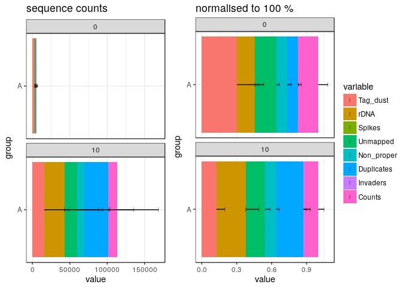

```r
ggpubr::ggarrange(
  plotAnnot( ce, scope = msScope_qcSI, group = "plateID", normalise = FALSE
           , title = "sequence counts"
           , facet="RNA") +
    facet_wrap(~facet, ncol = 1),
  plotAnnot( ce, scope = msScope_qcSI, group = "plateID", normalise = TRUE
         , title = "normalised to 100 %"
         , facet="RNA") +
  facet_wrap(~facet, ncol = 1),
  legend = "right",
  common.legend = TRUE
)
```

### 3.1.1 Removal of the RNA negative controls

To ease data handling, the negative controls with no RNA are removed.

```r
ce <- ce[,ce$RNA != 0]
```

```
## harmonizing input:
##   removing 7 sampleMap rows with 'colname' not in colnames of experiments
##   removing 7 colData rownames not in sampleMap 'primary'
```

## 3.2 By RT primer quantity

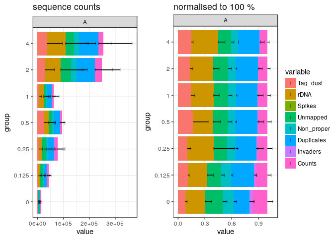

```r
ggpubr::ggarrange(
  plotAnnot( ce, scope = msScope_qcSI, group = "RT_PRIMERS", normalise = FALSE
           , title = "sequence counts"
           , facet="plateID") +
    facet_wrap(~facet, ncol = 1),
  plotAnnot( ce, scope = msScope_qcSI, group = "RT_PRIMERS", normalise = TRUE
         , title = "normalised to 100 %"
         , facet="plateID") +
  facet_wrap(~facet, ncol = 1),
  legend = "right",
  common.legend = TRUE
)
```

% invaders increases when [RT primers] decreases, reaching a maximum at 0. This suggests that demultiplexing is consistent. But why do we see a high promoter rate in the RT primer-negative controls ? If the only primers available are the TSOs, then some spurious intergenic counts should be found. If RNAs self-primed, then how could they be amplified during the cDNA PCR ?

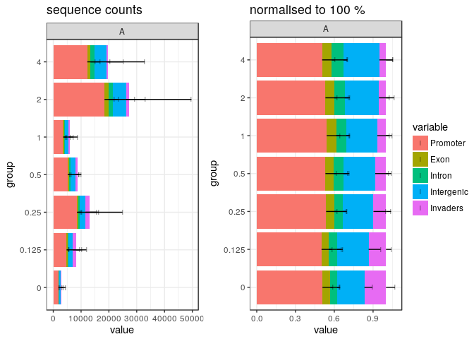

```r
ggpubr::ggarrange(
  plotAnnot( ce, scope = msScope_counts, group = "RT_PRIMERS", normalise = FALSE
           , title = "sequence counts"
           , facet="plateID") +
    facet_wrap(~facet, ncol = 1),
  plotAnnot( ce, scope = msScope_counts, group = "RT_PRIMERS", normalise = TRUE
         , title = "normalised to 100 %"
         , facet="plateID") +
  facet_wrap(~facet, ncol = 1),
  legend = "right",
  common.legend = TRUE
)
```

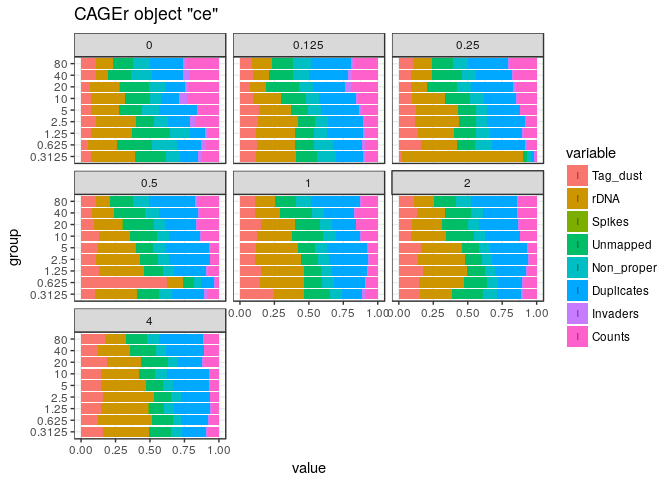

```r
plotAnnot( ce
         , scope = msScope_qcSI
         , group = "TSO", facet = "RT_PRIMERS")
```

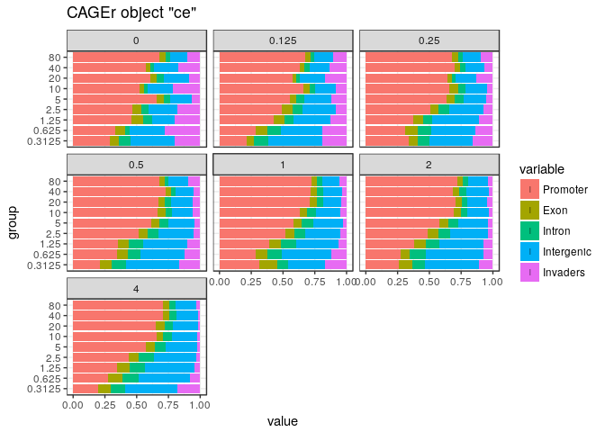

```r
plotAnnot( ce
         , scope = msScope_counts
         , group = "TSO", facet = "RT_PRIMERS")
```

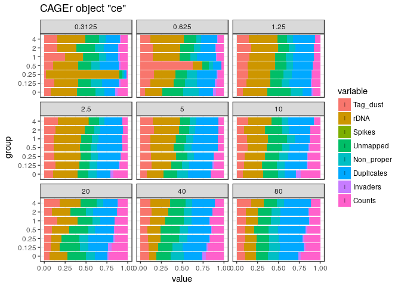

```r
plotAnnot( ce
         , scope = msScope_qcSI
         , group = "RT_PRIMERS", facet = "TSO")
```

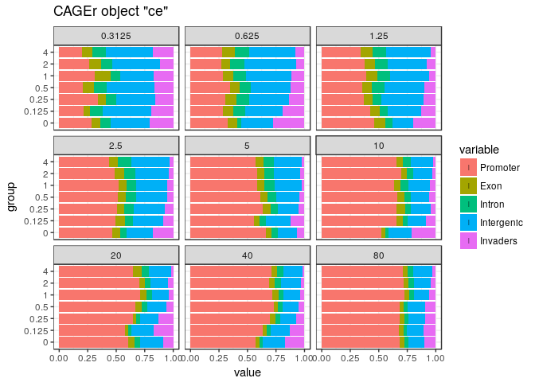

```r
plotAnnot( ce
         , scope = msScope_counts
         , group = "RT_PRIMERS", facet = "TSO")
```

### 3.2.1 Removal of the primer-negative controls

To ease data handling (for instance when working with primer ratios), the negative controls with no primers are removed.

```r
ce <- ce[,ce$RT_PRIMERS != 0]
```

```
## harmonizing input:
##   removing 9 sampleMap rows with 'colname' not in colnames of experiments
##   removing 9 colData rownames not in sampleMap 'primary'
```

Lets tidy the primer ratios after the null primer concentrations were removed.

```r
ce$PRIMERS_RATIO %<>% factor
levels(ce$PRIMERS_RATIO) %<>% as.numeric %>% signif(2) %>% as.character
ce$PRIMERS_RATIO %<>% factor(levels = levels(ce$PRIMERS_RATIO) %>% gtools::mixedsort())
```

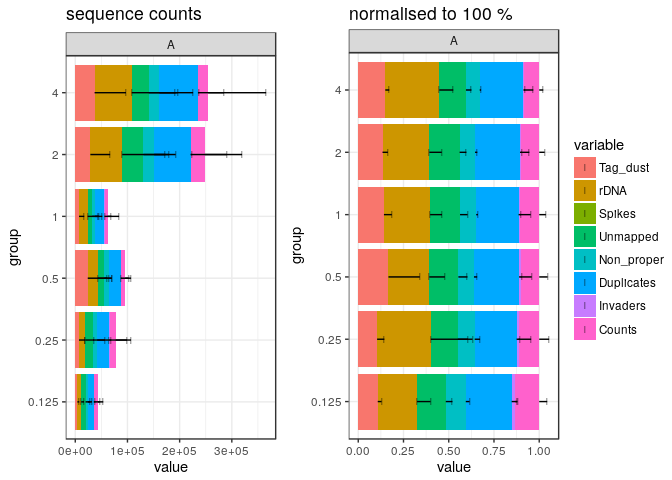

```r
ggpubr::ggarrange(
  plotAnnot( ce, scope = msScope_qcSI, group = "RT_PRIMERS", normalise = FALSE
           , title = "sequence counts"
           , facet="plateID") +
    facet_wrap(~facet, ncol = 1),
  plotAnnot( ce, scope = msScope_qcSI, group = "RT_PRIMERS", normalise = TRUE
         , title = "normalised to 100 %"
         , facet="plateID") +
  facet_wrap(~facet, ncol = 1),
  legend = "right",
  common.legend = TRUE
)
```

## 3.3 By TSO concentration

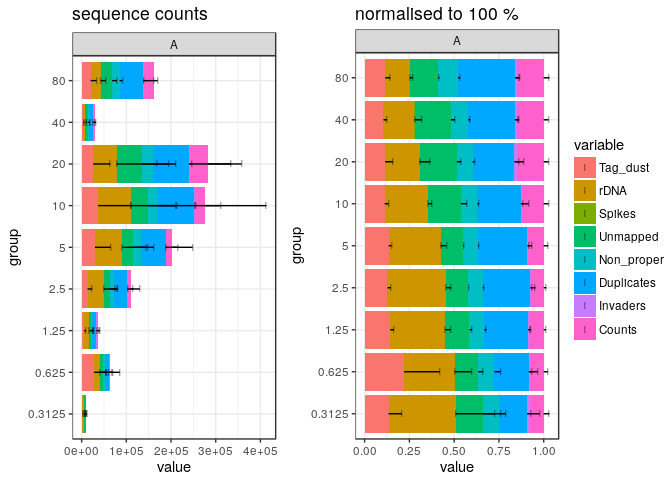

```r
ggpubr::ggarrange(
  plotAnnot( ce, scope = msScope_qcSI, group = "TSO", normalise = FALSE
           , title = "sequence counts"
           , facet="plateID") +
    facet_wrap(~facet, ncol = 1),
  plotAnnot( ce, scope = msScope_qcSI, group = "TSO", normalise = TRUE
         , title = "normalised to 100 %"
         , facet="plateID") +
  facet_wrap(~facet, ncol = 1),
  legend = "right",
  common.legend = TRUE
)
```

## 3.4 Create CTSS clusters

```r
# clusterCTSS(ce, thresholdIsTpm = FALSE, useMulticore = TRUE, nrPassThreshold = 2, removeSingletons = TRUE)
# cumulativeCTSSdistribution(ce, clusters = "tagClusters")
# #, use multicore = TRUE)
# quantilePositions(ce, clusters = "tagClusters", qLow = 0.1, qUp = 0.9, useMulticore = TRUE)
```

## 3.5 Annotation with GENCODE

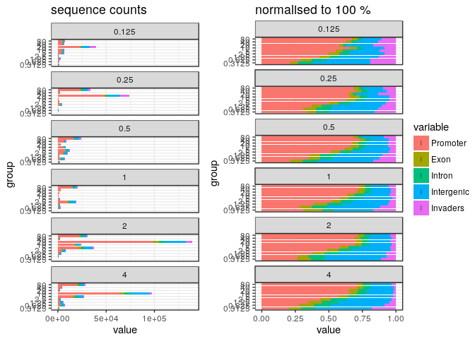

```r
ggpubr::ggarrange(
  plotAnnot( ce, scope = msScope_counts, group = "TSO", normalise = FALSE
           , title = "sequence counts"
           , facet="RT_PRIMERS") +
    facet_wrap(~facet, ncol = 1),
  plotAnnot( ce, scope = msScope_counts, group = "TSO", normalise = TRUE
         , title = "normalised to 100 %"
         , facet="RT_PRIMERS") +
  facet_wrap(~facet, ncol = 1),
  legend = "right",
  common.legend = TRUE
)
```

Make a gene expression table (not really required now).

```r
CTSStoGenes(ce)
#CTSScoordinatesGR(ce)
```